# Excess mortality

Alternative data sources

# Main data sources

## HMD yearly deaths with age structure

```r
hmd_deaths_age_sex <- read_rds("data/mortality_org/hmd_deaths_age_sex.Rds")
hmd_deaths_year <- read_rds("data/mortality_org/hmd_deaths_year.Rds")
hmd_pop_age_sex <- read_rds("data/mortality_org/hmd_pop_age_sex.Rds")
hmd_pop_year <- read_rds("data/mortality_org/hmd_pop_year.Rds")
```

## STMF weekly & monthly

```r
stmf_week <- read_rds("data/mortality_org/stmf_week.Rds")
stmf_month <- read_rds("data/mortality_org/stmf_month.Rds")
```

## BfS

```r
ch_deaths_month <- read_rds("data/BfS/ch_deaths_month.Rds")
```

# Switzerland

## Comparison - deaths

### BfS vs HMD

Aggregating monthly deaths from BfS to year.

```r
compare <- left_join(
  # ch_deaths_month_web %>%
  ch_deaths_month %>%
    group_by(Year) %>%
    summarise(deaths_year_bfs = sum(Deaths)),
  hmd_deaths_year %>%
    filter(Country == "Switzerland") %>%
    rename(deaths_year_hmd = Deaths)) %>%
  mutate(diff = deaths_year_bfs - deaths_year_hmd,
         perc = (deaths_year_bfs - deaths_year_hmd) / deaths_year_bfs)
```

Timeline of differences between yearly BfS and HMD figures.

#### Absolute

```r
summary(compare$diff)
```

```
    Min.  1st Qu.   Median     Mean  3rd Qu.     Max.
-77.0000   0.0000   0.0000  -0.2083   0.0000 117.0000
```

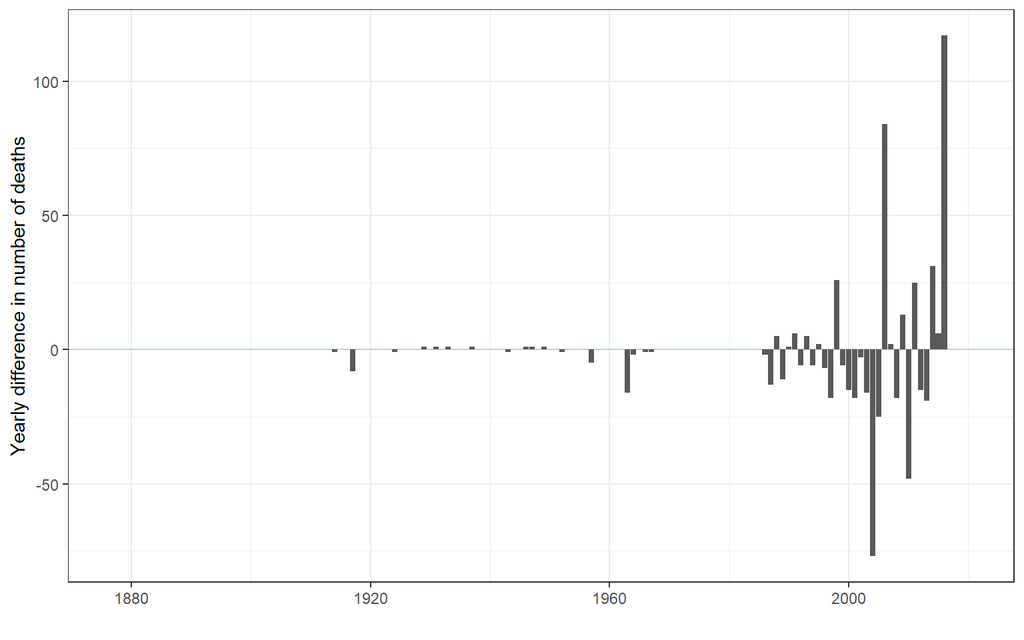

#### Percentage

```r
summary(compare$perc*100)
```

```
      Min.    1st Qu.     Median       Mean    3rd Qu.       Max.
-0.1279495  0.0000000  0.0000000 -0.0004441  0.0000000  0.1800998
```

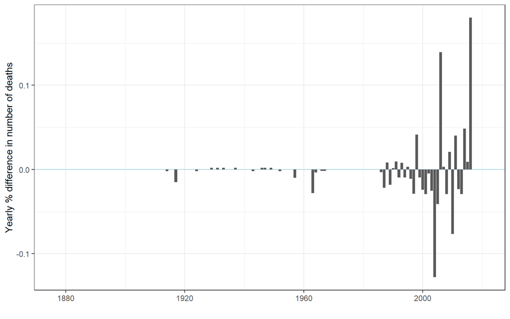

### BfS vs STMF

Comparing monthly figures.[^1]

```r
compare <- inner_join(
  ch_deaths_month %>%
    rename(deaths_bfs = Deaths),
  stmf_month %>%
    filter(Country == "Switzerland") %>%
    rename(deaths_stmf = Deaths)
) %>%
  mutate(diff = deaths_bfs - deaths_stmf,
         perc = (deaths_bfs - deaths_stmf) / deaths_bfs)
```

Summary of differences between monthly BfS and STMF figures.

#### Absolute

```r
summary(compare$diff)
```

```
   Min. 1st Qu.  Median    Mean 3rd Qu.    Max.
-93.000 -15.000   0.000   3.087  19.250 470.000
```

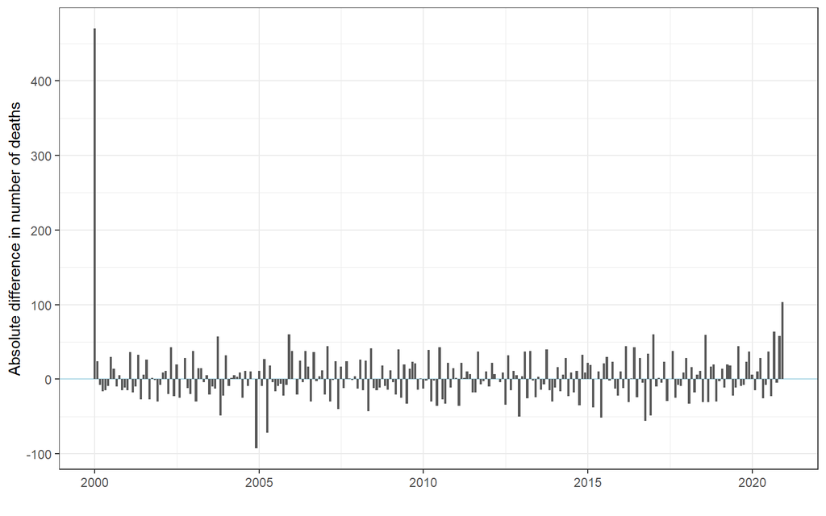

#### Percentage

```r
summary(compare$perc*100)
```

```
    Min.  1st Qu.   Median     Mean  3rd Qu.     Max.
-1.74648 -0.28899  0.00000  0.03763  0.36282  6.63748
```

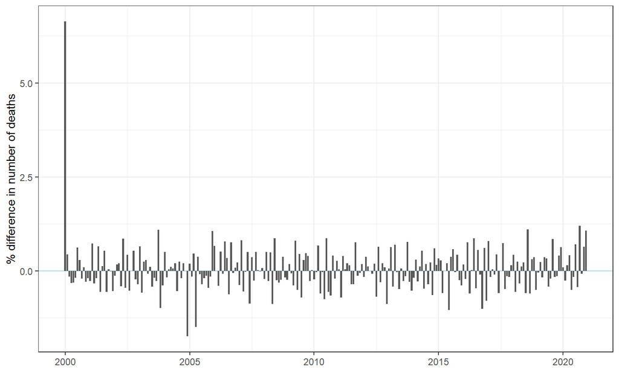

## Yearly 2019-2020 deaths with age & sex structure

Data from BfS website [Deaths by sex, citizenship, marital status and age](https://www.bfs.admin.ch/bfs/en/home/statistics/population.assetdetail.17664400.html).[^2]

```r
ch_deaths_age_sex_2019_2020 <- read.px("data-raw/BfS/px-x-0102020206_103.px") %>%
  as_tibble() %>% remove_empty() %>% clean_names() %>%
  filter(zivilstand == "Zivilstand - Total",
         staatsangehorigkeit == "Staatsangehörigkeit - Total") %>%
  select(-zivilstand, -staatsangehorigkeit) %>%
  filter(alter != "Alter - Total") %>%
  rename(Year = jahr,
         Total = value) %>%
  mutate(Year = as.integer(as.character(Year)),
         geschlecht = as.character(geschlecht),
         Age = as.integer(word(alter, 1)),
         Total = as.integer(round(Total))) %>%
  filter(Year >= 2019) %>%
  select(-alter) %>%
  mutate(geschlecht = if_else(geschlecht == "Geschlecht - Total", "Total", geschlecht)) %>%
  mutate(geschlecht = if_else(geschlecht == "Mann", "Male", geschlecht)) %>%
  mutate(geschlecht = if_else(geschlecht == "Frau", "Female", geschlecht)) %>%
  pivot_wider(names_from = geschlecht, values_from = Total) %>%
  mutate(Country = "Switzerland") %>%
  relocate(Country, Year, Age, Female, Male, Total)
```

### Comparison to HMD results for 2019 & 2020.

```r
compare <- hmd_deaths_age_sex %>%
  filter(Country == "Switzerland" & Year >= 2019) %>%
  mutate(Age = ifelse(Age > 100, 100, Age)) %>%
  select(-Female, -Male) %>%
  group_by(across(c(-Total))) %>%
  summarise(Total = sum(Total)) %>%
  ungroup() %>%
  rename(Total_hmd = Total) %>%
  left_join(ch_deaths_age_sex_2019_2020 %>%
              mutate(Age = ifelse(Age > 100, 100, Age)) %>%
              select(-Female, -Male) %>%
              group_by(across(c(-Total))) %>%
              summarise(Total = sum(Total)) %>%
              ungroup() %>%
              rename(Total_bfs = Total)
  ) %>%
  mutate(diff = Total_bfs - Total_hmd,
         diff_p = ((Total_bfs - Total_hmd) / Total_hmd) *100)
```

#### Absolute difference

```r
summary(compare$diff)
```

```
   Min. 1st Qu.  Median    Mean 3rd Qu.    Max.
 -178.0   -18.5    -2.0     0.0     4.0   236.0
```

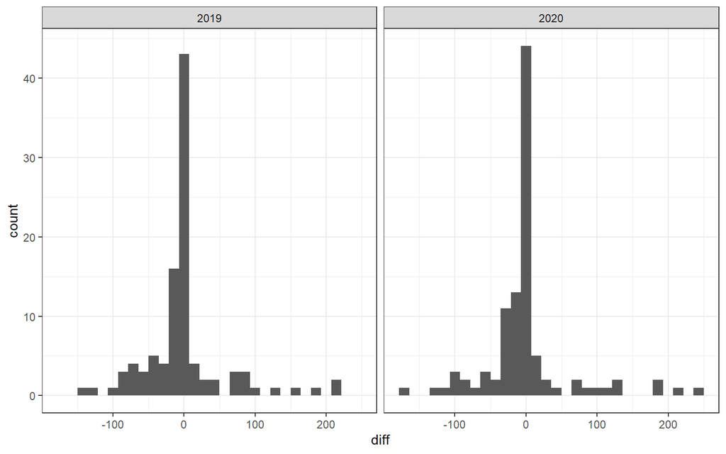

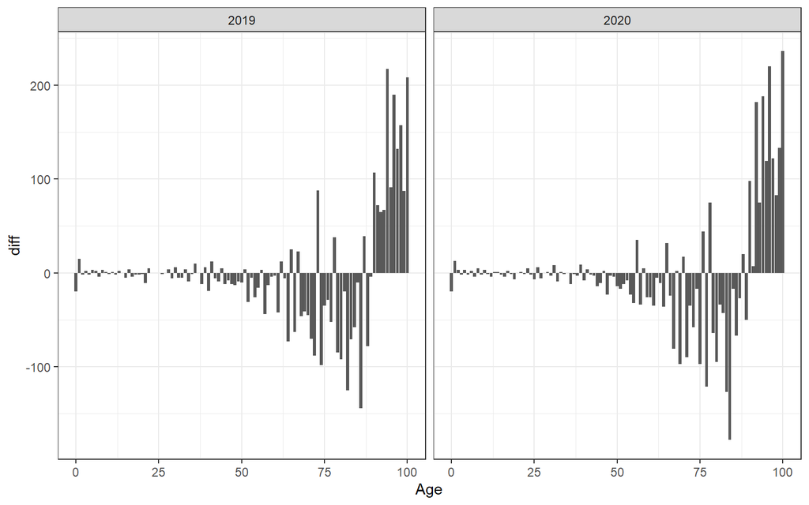

#### Percentage difference

```r
summary(compare$diff_p)
```

```
    Min.  1st Qu.   Median     Mean  3rd Qu.     Max.
-50.0000  -7.0216  -2.0166   0.7486   3.8990 125.0000
```

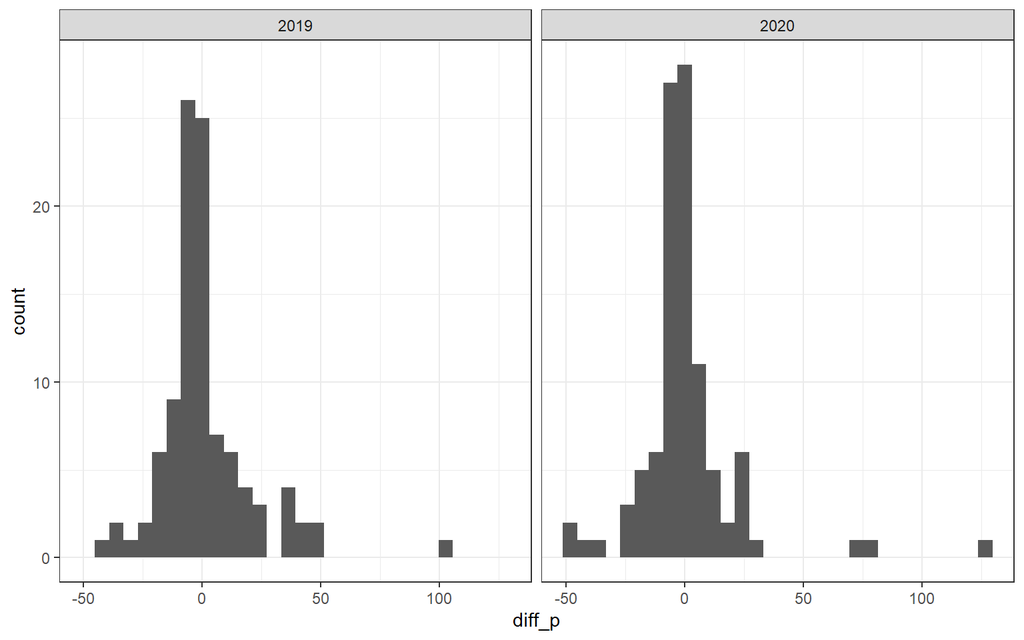

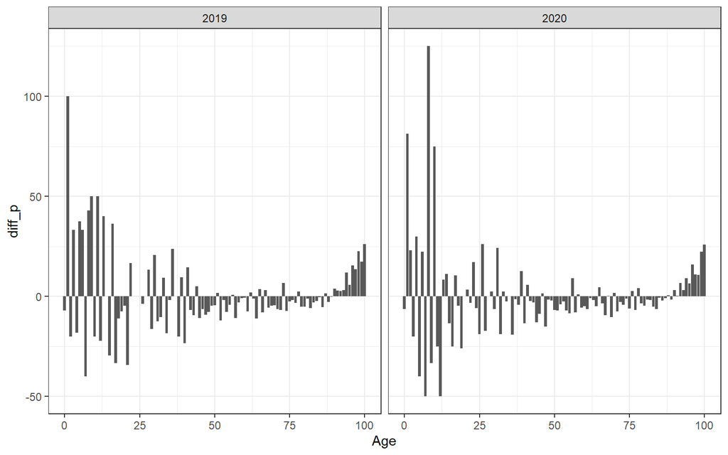

## Yearly pops untill 2020

```r
ch_pop_year <- read_xlsx("data-raw/BfS/su-e-01.02.04.05.xlsx",
                         na = "...", skip = 1) %>%
  remove_empty(c("rows", "cols")) %>%
  clean_names() %>%
  rename(Year = x1, pop_jan = population_on_2, pop_dec = population_on_11) %>%
  filter(!is.na(Year)) %>%
  filter(!is.na(pop_jan)) %>%
  mutate(Year = if_else(Year == "2010 7", "2010", Year),
         Year = as.integer(Year),
         pop_jan = as.integer(pop_jan),
         pop_dec = as.integer(pop_dec)) %>%
  select(Year, starts_with("pop_"))
```

### Comparison to HMD

BfS vs HMD

```r
compare <- left_join(
  ch_pop_year,
  hmd_pop_year %>% filter(Country == "Switzerland") %>% rename(HMD_pop = Population)) %>%
  select(-Country) %>%
  mutate(diff1 = pop_jan - HMD_pop,
         diff2 = pop_dec - HMD_pop)
```

#### January

Difference between **Jan** pop from BfS and **yearly** pop from HMD

```r
summary(compare$diff1)
```

```
   Min. 1st Qu.  Median    Mean 3rd Qu.    Max.    NA's
-3777.0   -88.0   378.0   942.6   762.0  9723.0      15
```

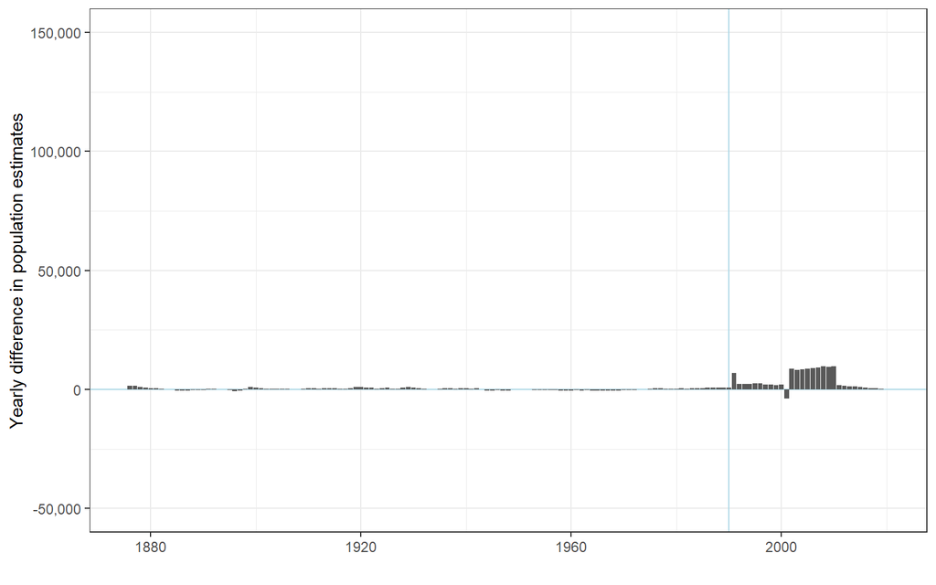

#### Dec

Difference between **Dec** pop from BfS and **yearly** pop from HMD

```r
summary(compare$diff2)
```

```
   Min. 1st Qu.  Median    Mean 3rd Qu.    Max.    NA's
 -36450   19747   38145   41734   61714  147995      15
```

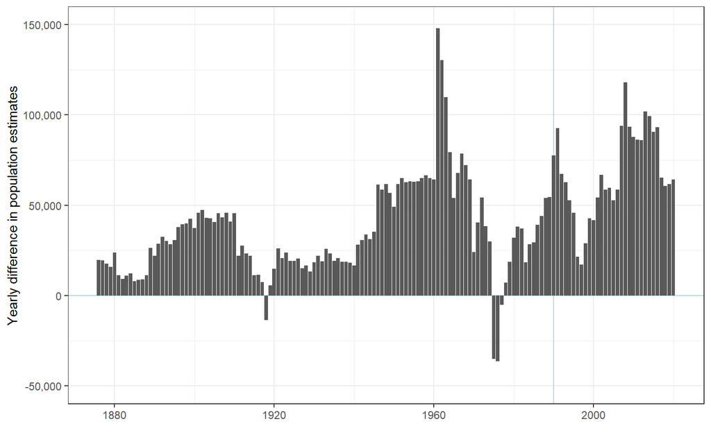

## Yearly pops with age structure

### Comparison - HMD vs BfS 1

Data from `px-x-0102030000_101`: *Permanent resident population by sex and age, 1860-2020* [(source)](https://www.bfs.admin.ch/bfs/en/home/statistics/catalogues-databases/data.assetdetail.19105850.html). With info from docs:

> Reference day: 31 December

```r
ch_pop_age_sex <- read.px("data-raw/BfS/px-x-0102030000_101.px") %>%
  as_tibble() %>% remove_empty() %>% clean_names() %>%
  filter(alter != "Alter - Total",
         geschlecht == "Geschlecht - Total") %>%
  rename(Year = jahr) %>%
  mutate(Year = as.integer(as.character(Year)),
         Age = as.integer(word(alter, 1)),
         Population = as.integer(round(value))) %>%
  select(-alter, -geschlecht, -value)
```

We have a bit of discrepancy going on in the data. Example of 2020:

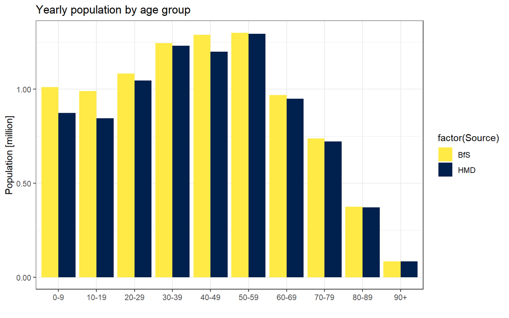

```r
hmd_pop_age_sex %>%
  filter(Country == "Switzerland") %>%
  filter(Year == 2020) %>%
  mutate(Age_cat = cut(Age, c(seq(0, 90, 10),120),
                       include.lowest = TRUE,
                       right = FALSE,
                       labels=c("0-9","10-19","20-29","30-39","40-49",
                                "50-59","60-69","70-79","80-89","90+"))) %>%
  group_by(Year, Age_cat) %>%
  summarise(Population = sum(Total)) %>%
  ungroup() %>%
  mutate(Source = "HMD") %>%
  bind_rows(
    ch_pop_age_sex %>%
      mutate(Age_cat = cut(Age, c(seq(0, 90, 10),120),
                           include.lowest = TRUE,
                           right = FALSE,
                           labels=c("0-9","10-19","20-29","30-39","40-49",
                                    "50-59","60-69","70-79","80-89","90+"))) %>%
      group_by(Year, Age_cat) %>%
      summarise(Population = sum(
        # population_on_1_january
        # Total
        # population_on_31_december
        Population
      )) %>%
      ungroup() %>%
      mutate(Source = "BfS")
  ) %>%
  ggplot(
    aes(x = Age_cat, y = Population / 1000000,
        fill = factor(Source))) +
  geom_col(position = "dodge") +
  scale_y_continuous(labels = comma) +
  theme_bw() +
  scale_fill_viridis_d(option = "E", direction = -1) +
  xlab("") + ylab("Population [million]") +
  labs(title = "Yearly population by age group")
```

### Comparison - HMD vs BfS 2

Using data from `px-x-0102020000_104`: *Demographic balance by age and canton* [(source)](https://www.pxweb.bfs.admin.ch/pxweb/en/px-x-0102020000_104/-/px-x-0102020000_104.px).

Again 2020 used for examples:

```r
ch_pop_age_sex_2020 <- read_xlsx("data-raw/BfS/px-x-0102020000_104_AGE.xlsx",
                                 col_types = c("skip", "skip", "skip",
                                               "skip", "skip", "text", "numeric",
                                               "numeric"), skip = 2) %>%
  remove_empty(which = c("rows", "cols")) %>%
  clean_names() %>%
  rename(Age = x1) %>%
  filter(Age != "No indication") %>%
  mutate(Age = str_replace(Age, fixed(" years"), "")) %>%
  mutate(Age = str_replace(Age, fixed(" year"), "")) %>%
  mutate(Age = str_replace(Age, fixed(" or older"), "")) %>%
  mutate(Age = as.integer(Age)) %>%
  mutate(Country = "Switzerland",
         Year = as.integer(2020)) %>%
  relocate(Country, Year, Age)
```

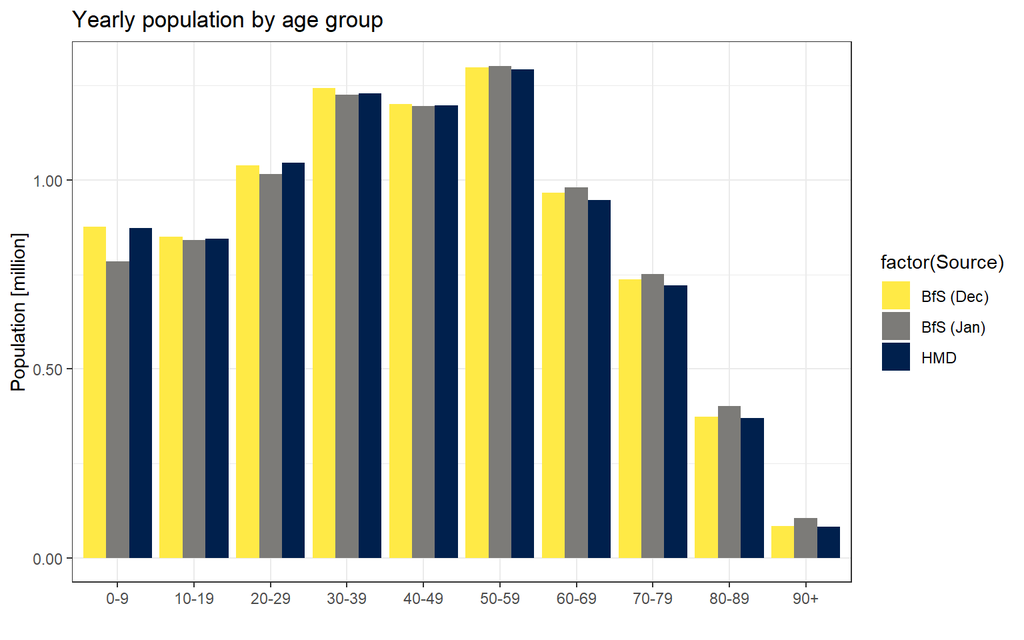

```r
bind_rows(
  hmd_pop_age_sex %>%
    filter(Country == "Switzerland") %>%
    filter(Year == 2020) %>%
    mutate(Age_cat = cut(Age, c(seq(0, 90, 10),120),
                         include.lowest = TRUE,
                         right = FALSE,
                         labels=c("0-9","10-19","20-29","30-39","40-49",
                                  "50-59","60-69","70-79","80-89","90+"))) %>%
    group_by(Year, Age_cat) %>%
    summarise(Population = sum(Total)) %>%
    ungroup() %>%
    mutate(Source = "HMD"),

  ch_pop_age_sex_2020 %>%
    mutate(Age_cat = cut(Age, c(seq(0, 90, 10),120),
                         include.lowest = TRUE,
                         right = FALSE,
                         labels=c("0-9","10-19","20-29","30-39","40-49",
                                  "50-59","60-69","70-79","80-89","90+"))) %>%
    group_by(Year, Age_cat) %>%
    summarise(Population = sum(
      population_on_31_december
    )) %>%
    ungroup() %>%
    mutate(Source = "BfS (Dec)"),

  ch_pop_age_sex_2020 %>%
    mutate(Age_cat = cut(Age, c(seq(0, 90, 10),120),
                         include.lowest = TRUE,
                         right = FALSE,
                         labels=c("0-9","10-19","20-29","30-39","40-49",
                                  "50-59","60-69","70-79","80-89","90+"))) %>%
    group_by(Year, Age_cat) %>%
    summarise(Population = sum(
      population_on_1_january
    )) %>%
    ungroup() %>%
    mutate(Source = "BfS (Jan)")

) %>%

  ggplot(
    aes(x = Age_cat, y = Population/1000000,
        fill = factor(Source))) +
  geom_col(position = "dodge") +
  scale_y_continuous(labels = comma) +
  theme_bw() +
  scale_fill_viridis_d(option = "E", direction = -1) +
  xlab("") + ylab("Population [million]") +
  labs(title = "Yearly population by age group")
```

# Spain

## Yearly pops

INE data until 2019.

```r
es_pop_year <- read_xlsx("data-raw/INE/Spain_population.xlsx") %>%
  remove_empty(which = c("rows", "cols")) %>%
  clean_names() %>%
  rename(Year = year) %>%
  rename(Population = prados_de_la_escosura2020_july) %>%
  select(Year, Population) %>%
  mutate(Year = as.integer(Year),
         Population = as.integer(round(Population))) %>%
  filter(Year != 2020)
```

### Comparison with HMD

Difference between yearly INE and HMD pops.

```r
compare <- left_join(
  es_pop_year %>% rename(INE_pop = Population),
  hmd_pop_year %>% filter(Country == "Spain") %>% rename(HMD_pop = Population)) %>%
  select(-Country) %>%
  mutate(diff = INE_pop - HMD_pop,
         diff_perc = (INE_pop - HMD_pop) / INE_pop)
```

#### Absolute

```r
summary(compare$diff)
```

```
   Min. 1st Qu.  Median    Mean 3rd Qu.    Max.    NA's
-431813  -16723   50649   67168  172370  561318       8
```

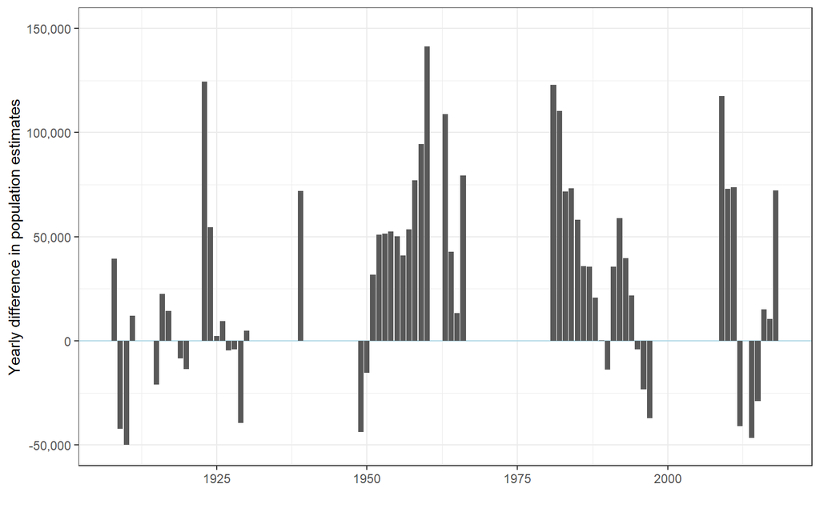

#### Realtive

```r
summary(compare$diff_perc)
```

```
     Min.   1st Qu.    Median      Mean   3rd Qu.      Max.      NA's
-0.016846 -0.000592  0.001530  0.001898  0.004961  0.021694         8
```

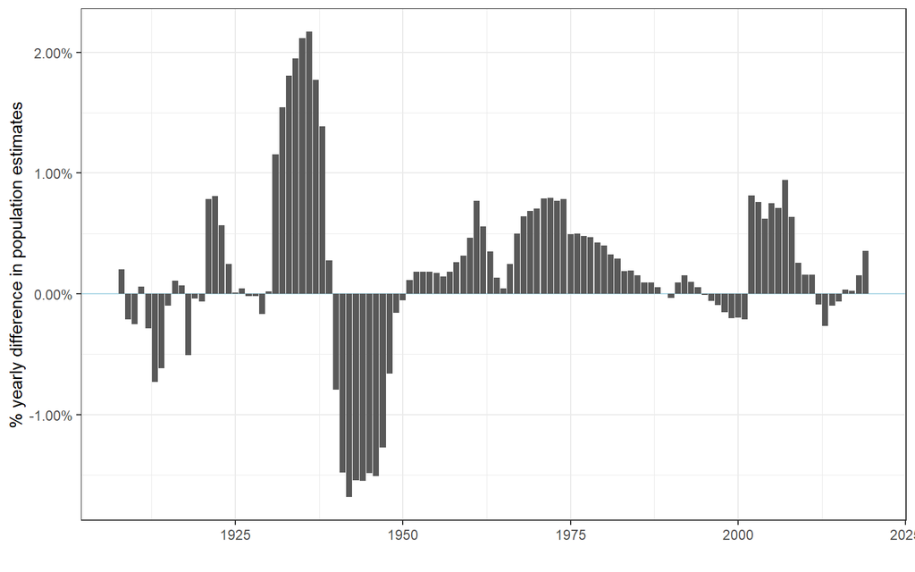

## Yearly pops 2020 & 2021

Data available from [here](https://www.ine.es/jaxiT3/Tabla.htm?t=31304).

Nothing to compare against since HMD stops in 2019 for ESP :/

```r
es_pop_year <- hmd_pop_year %>%
  filter(Country == "Spain")

es_pop_2020 <-
  read_excel("data-raw/INE/Spain_Population_age-2019.xlsx",
             sheet=1,range="A8:H212") %>%
  slice(., -(1:2)) %>%
  select(1,8) %>%
  rename(Population=`Both sexes...8`) %>%
  filter(!is.na(Population)) %>%
  summarize(Population = sum(Population, na.rm = TRUE)) %>%
  mutate(Year = as.integer(2020),
         Population = as.integer(Population),
         Country = "Spain")

es_pop_2021 <-
  read_excel("data-raw/INE/Spain_Population_age-2019.xlsx",
             sheet=1,range="A8:B212") %>%
  slice(., -(1:2)) %>%
  rename(Population=`Both sexes`) %>%
  filter(!is.na(Population)) %>%
  summarize(Population = sum(Population, na.rm = TRUE)) %>%
  mutate(Year = as.integer(2021),
         Population = as.integer(Population),
         Country = "Spain")

es_pop_year %<>%
  bind_rows(es_pop_2020) %>%
  bind_rows(es_pop_2021) %>%
  fill(Country, .direction = "down")
```

## Pops with age structure 2020 & 2021

Nothing to compare against since HMD stops in 2019 for ESP :/

# Sweden

## 2020 deaths with age & sex structure

Data from SCB.

```r
se_deaths_age_sex_2020 <- read_xlsx("data-raw/SCB/BE0101D9_20210429-200440.xlsx",
                                    col_types = c("text", "text", "text", "numeric", "numeric"),
                                    skip = 2) %>%
  remove_empty(which = c("rows", "cols")) %>%
  clean_names() %>%
  filter(!is.na(x2020)) %>%
  select(-x1, -x2019) %>%
  mutate(x3 = if_else(x3 == "men", "Male", "Female")) %>%
  fill(x2) %>%
  pivot_longer(cols = x2020, names_to = "Year") %>%
  rename(Age = x2, Sex = x3) %>%
  mutate(Year = as.integer(str_replace(Year, fixed("x"), "")),
         Age = word(Age, 1),
         Age = str_replace(Age, fixed("100+"), "100"),
         Age = as.integer(Age)) %>%
  pivot_wider(names_from = Sex, values_from = value) %>%
  mutate(Male = as.integer(round(Male)),
         Female = as.integer(round(Female))) %>%
  mutate(Total = Male + Female) %>%
  arrange(Year, Age) %>%
  mutate(Country = "Sweden") %>% relocate(Country)
```

### Comparison to HMD results for 2020.

```r
compare <-
  hmd_deaths_age_sex %>%
  filter(Country == "Sweden" & Year == 2020 ) %>%
  mutate(Age = ifelse(Age > 100, 100, Age)) %>%
  select(-Female, -Male) %>%
  group_by(across(c(-Total))) %>%
  summarise(Total = sum(Total)) %>%
  ungroup() %>%
  rename(Total_hmd = Total) %>%
  left_join(
    se_deaths_age_sex_2020 %>%
      mutate(Age = ifelse(Age > 100, 100, Age)) %>%
      select(-Female, -Male) %>%
      group_by(across(c(-Total))) %>%
      summarise(Total = sum(Total)) %>%
      ungroup() %>%
      rename(Total_scb = Total)
  ) %>%
  mutate(diff = Total_scb - Total_hmd,
         diff_p = ((Total_scb - Total_hmd) / Total_hmd) *100)
```

#### Absolute difference

```r
summary(compare$diff)
```

```
   Min. 1st Qu.  Median    Mean 3rd Qu.    Max.
      0       0       0       0       0       0
```

#### Percentage difference

```r
summary(compare$diff_p)
```

```
   Min. 1st Qu.  Median    Mean 3rd Qu.    Max.
      0       0       0       0       0       0
```

## Yearly pops

```r
se_pop_year <- read_xlsx("data-raw/SCB/be0101_tab9utveng1749-2020.xlsx",
                         skip = 4) %>%
  remove_empty(which = c("rows", "cols")) %>%
  clean_names() %>%
  rename(Population = population) %>%
  select(year, Population) %>%
  filter(!is.na(Population)) %>%
  mutate(year = ifelse(year == "20001)", 2000, year),
         year = as.integer(year),
         Population = as.integer(round(Population))) %>%
  rename(Year = year)
```

### Comparison with HMD

SCB vs HMD

```r
compare <- left_join(
  hmd_pop_year %>% filter(Country == "Sweden") %>% rename(HMD_pop = Population),
  se_pop_year %>% rename(SCB_pop = Population)
) %>%
  select(-Country) %>%
  mutate(diff = SCB_pop - HMD_pop,
         diff_perc = (SCB_pop - HMD_pop) / SCB_pop)
```

Difference between yearly SCB and HMD pops.

#### Absolute

```r
summary(compare$diff)
```

```
   Min. 1st Qu.  Median    Mean 3rd Qu.    Max.    NA's
 -39251   18546   31809   33580   44477  144379       1
```

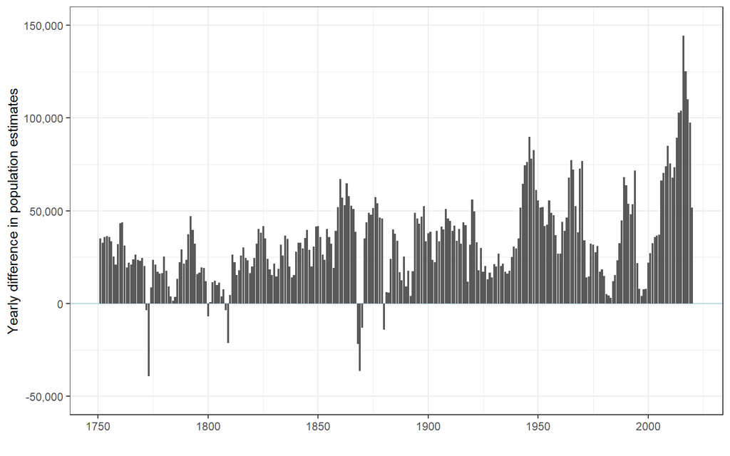

#### Realtive

```r
summary(compare$diff_perc)
```

```
     Min.   1st Qu.    Median      Mean   3rd Qu.      Max.      NA's
-0.019852  0.004123  0.007455  0.007411  0.010386  0.022562         1
```

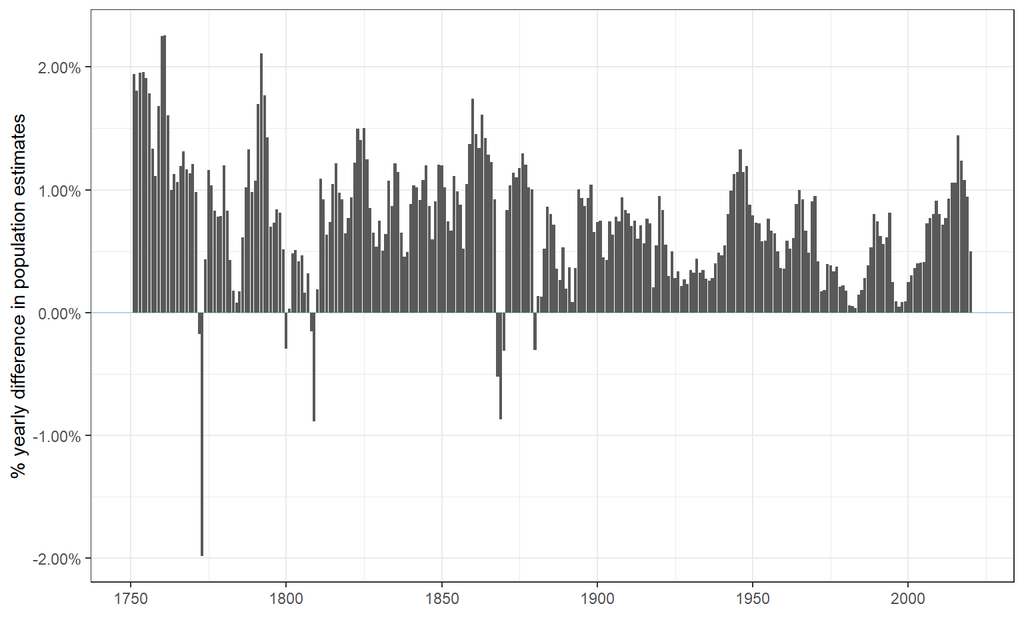

To cite R in publications use:

R Core Team (2021). *R: A Language and Environment for Statistical Computing*. R Foundation for Statistical Computing, Vienna, Austria. https://www.R-project.org/.

To cite the `ggplot2` package in publications use:

Wickham H (2016). *ggplot2: Elegant Graphics for Data Analysis*. Springer-Verlag New York. ISBN 978-3-319-24277-4, https://ggplot2.tidyverse.org.

[^1]: see data prep document for week <> month issues!
[^2]: Or in custom tabs [here](https://www.pxweb.bfs.admin.ch/pxweb/en/px-x-0102020206_103/px-x-0102020206_103/px-x-0102020206_103.px/).
[^3]: Alternative source might be [here](https://www.bfs.admin.ch/bfs/en/home/statistics/catalogues-databases/data.assetdetail.19105850.html).